# Data 605 HW14

William Jasmine

2023-05-04

# Functions and Imports

The code below imports the necessary packages, and defines a function that can be used to graph Taylor Expansion estimates.

```r
library(pracma)


graph_taylor <- function(f_to_approximate, a, x_min, x_max){

  # f_to_approximate: function to find expansion of.
  # a: center point of taylor expansion.
  # x_min: min x value to estimate.
  # x_max: max x value to estimate.

  xs <- seq(x_min, x_max, 0.01)
  fx <- f(xs)

  plot(xs,fx,type="l",col="red")

  for(n in 1:8) {
    fx_T <- c()
    for(i in 1:length(xs)){
      coefs <- rev(taylor(f_to_approximate, a, n))
      est <- polyval(coefs, xs[i])
      est <- 0
      for(j in 1:length(coefs)){
        est <- est + (coefs[j] * xs[i]^(j-1))
      }
      fx_T[i] <- est
    }
    lines(xs,fx_T,col="green")
  }

  lines(xs,fx,type="l",col="red")
}
```

# Description

This assignment focuses on finding the Taylor Series expansions of the following functions:

- $f(x) = \frac{1}{1-x}$
- $f(x) = e^x$
- $f(x) = \ln{(1+x)}$
- $f(x) = \sqrt{x}$

# Definitions

The Taylor Series expansion of $f(x)$ centered at (or about) a point $x=a$, is defined as the following:

$$\begin{equation}
TSE(f) = \sum_{n=0}^{\infty} \frac{f^{(n)}(a)}{n!}(x-a)^n
\end{equation}$$

From the definition of above, it is clear that a Taylor expansion for $f(x)$ only exists given that $f(x)$ is infinitely differentiable at $a$.

Furthermore, once a Taylor Series expansion has been determined for $f(x)$ centered at $a$, we can say that $f(x) = TSE(f)$ on the interval for which $TSE(f)$ converges. To find the interval of convergence $l$ of a sum we can use the ratio test. To perform a ratio test, assume a power series $\sum a_n$ and define:

$$L = \lim_{n\to\infty}\left| \frac{a^{n+1}}{a^n} \right|$$

The ratio test says that:

1. If $L < 1$, the series is absolutely convergent (converges everywhere).
2. If $L > 1$, the series is divergent.
3. If $L = 1$, the series may be divergent, conditionally convergent, or absolutely convergent.

Thus, we can use the above to determine the interval over which a function is exactly equal to its Taylor Series expansion (in the limit that $n \to \infty$.)

# Function 1

## Derive Exspansion

First, we find the Taylor Series expansion for $f(x) = \frac{1}{1-x}$. We will choose $a=0$ as the center point, given that $f(x)$ is differentiable at this point. To assist in computing the first few terms of the sum, the table below tracks the different values of $f^{(n)}(x)$ and $f^{(n)}(a)=f^{(n)}(0)$ for the first few values of $n$:

| $n$ | $n!$ | $f^{(n)}(x)$ | $f^{(n)}(0)$ |
| --- | --- | --- | --- |
| 0 | 1 | $\frac{1}{1-x}$ | 1 |
| 1 | 1 | $\frac{1}{(1-x)^2}$ | 1 |
| 2 | 2 | $\frac{2}{(1-x)^3}$ | 2 |
| 3 | 6 | $\frac{6}{(1-x)^4}$ | 6 |

Thus, the Taylor Series expansion of $f(x)$ is:

$$\begin{align}
TSE(f) &= \frac{1}{1}(x-0)^0 + \frac{1}{1}(x-0)^1 +
\frac{2}{2}(x-0)^2 + \frac{6}{6}(x-0)^3 + \ ...\\
&= 1 + x + x^2 + x^3 + \ ... \\
&= \sum_{n=0}^{\infty}x^n
\end{align}$$

We can determine the interval of convergence of this sum by applying the ratio test:

$$\begin{align}
L &= \lim_{n\to\infty}\left| \frac{a^{n+1}}{a^n} \right| \\
&= \lim_{n\to\infty}\left| \frac{x^{n+1}}{x^n} \right| \\
&= \lim_{n\to\infty}\left| x \right| \\
&= |x|
\end{align}$$

Thus, the series converges when $|x| < 1$, or $-1 < x < 1$. Thus, $f(x) = \frac{1}{1-x} =\sum_{n=0}^{\infty}x^n$ on the interval $(-1, 1)$.

## Graph Estimate

The following code produces a graph of the function $f(x) = \frac{1}{1+x}$ in red, along with its Taylor Series approximations using 1 up to 8 terms (in green) and $x=0$ as the center point.

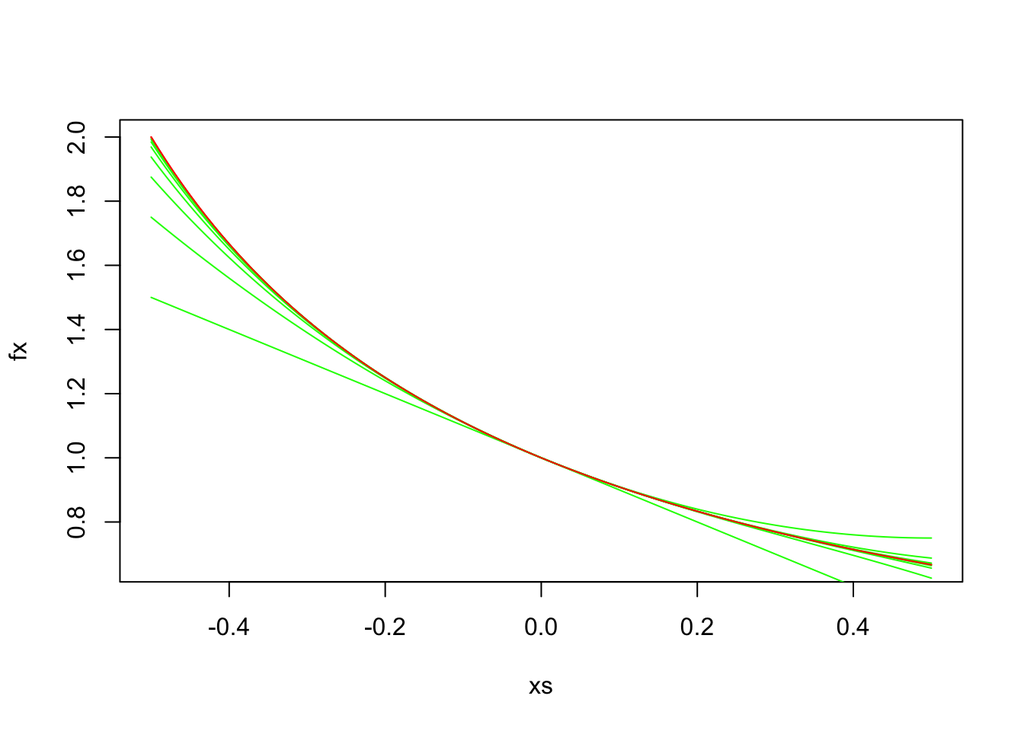

```r
f <- function(x) {
  return(1 / (1+x))
}

graph_taylor(f, 0, -0.5, 0.5)
```

# Function 2

## Derive Exspansion

To find the Taylor Series expansion for $f(x) = e^x$, we can repeat the same process from that was used for the previous function. Once again, we will choose $a=0$ as the center point, given that $f(x)$ is differentiable at this point. The chart:

| $n$ | $n!$ | $f^{(n)}(x)$ | $f^{(n)}(0)$ |
| --- | --- | --- | --- |
| 0 | 1 | $e^x$ | 1 |
| 1 | 1 | $e^x$ | 1 |
| 2 | 2 | $e^x$ | 1 |
| 3 | 6 | $e^x$ | 1 |

Thus, the Taylor Series expansion of $f(x)$ is:

$$\begin{align}
TSE(f) &= \frac{1}{1}(x-0)^0 + \frac{1}{1}(x-0)^1 +
\frac{1}{2}(x-0)^2 + \frac{1}{6}(x-0)^3 + \ ...\\
&= 1 + x + \frac{x^2}{2} + \frac{x^3}{6} + \ ... \\
&= \sum_{n=0}^{\infty}\frac{x^n}{n!}
\end{align}$$

We can determine the interval of convergence of this sum by applying the ratio test:

$$\begin{align}
L &= \lim_{n\to\infty}\left| \frac{a^{n+1}}{a^n} \right| \\
&= \lim_{n\to\infty}\left| \frac{x^{n+1}}{(n+1)!}\cdot
\frac{n!}{x^n} \right| \\
&= \lim_{n\to\infty}\left| \frac{x}{n+1} \right| \\
&= 0
\end{align}$$

Since $L<1$, we know that the Taylor Series expansion of $e^x$ converges everywhere. Thus, $f(x) = e^x =\sum_{n=0}^{\infty}\frac{x^n}{n!}$ on the interval $(-\infty, \infty)$ (in other words, they’re always equal).

## Graph Estimate

The following code produces a graph of the function $f(x) = e^x$ in red, along with its Taylor Series approximations using 1 up to 8 terms (in green) and $x=0$ as the center point.

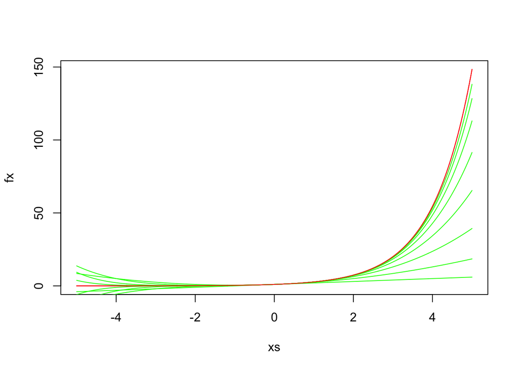

```r
f <- function(x) {
  return(exp(x))
}

graph_taylor(f, 0, -5, 5)
```

# Function 3

## Derive Expansion

We repeat the process again for the function $f(x) = \ln(1+x)$, once again centering on $x=0$:

| $n$ | $n!$ | $f^{(n)}(x)$ | $f^{(n)}(0)$ |
| --- | --- | --- | --- |
| 0 | 1 | $\ln{(1+x)}$ | 0 |
| 1 | 1 | $\frac{1}{1+x}$ | 1 |
| 2 | 2 | $-\frac{1}{(1+x)^2}$ | -1 |
| 3 | 6 | $\frac{2}{(1+x)^3}$ | 2 |
| 4 | 24 | $-\frac{6}{(1+x)^4}$ | -6 |

We can determine the interval of convergence of this sum by applying the ratio test:

$$\begin{align}
L &= \lim_{n\to\infty}\left| \frac{a^{n+1}}{a^n} \right| \\
&= \lim_{n\to\infty}\left| \frac{(-1)^{n+2}x^{n+1}}{n+1} \cdot
\frac{n}{(-1)^{n+1}x^n} \right| \\
&= \lim_{n\to\infty}\left| -\frac{xn}{n+1} \right| \\
&= |-x| \\
&= |x|
\end{align}$$

From function 1, we already know this means the sum converges on the interval $(-1, 1)$. Thus, $f(x) = \ln(1+x) =\sum_{n=1}^{\infty}(-1)^{n+1}\frac{x^n}{n}$ on the interval $(-1, 1)$.

## Graph Estimate

The following code produces a graph of the function $f(x) = \ln{(1+x)}$ in red, along with its Taylor Series approximations using 1 up to 8 terms (in green) and $x=0$ as the center point.

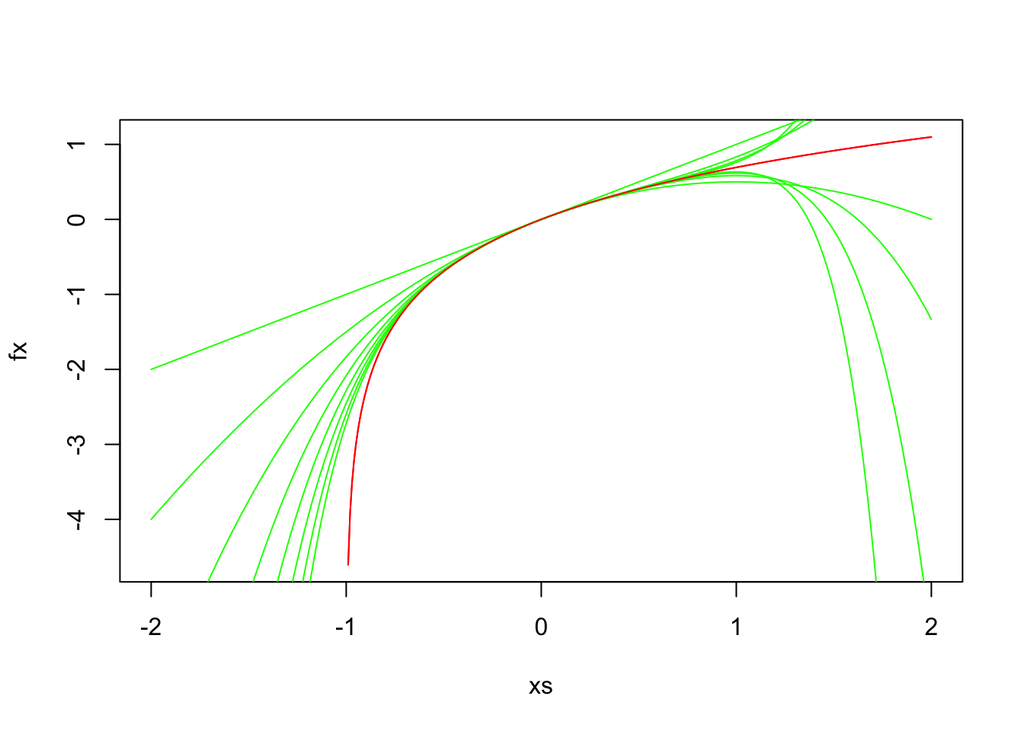

```r
f <- function(x) {
  return(log(1 + x))
}

graph_taylor(f, 0, -2, 2)
```

# Function 4

## Derive Expansion

The function $f(x)=\sqrt{x}$ is not differentiable at 0, and thus for this function we will instead use $a=1$:

| $n$ | $n!$ | $f^{(n)}(x)$ | $f^{(n)}(1)$ |
| --- | --- | --- | --- |
| 0 | 1 | $x^{1/2}$ | 1 |
| 1 | 1 | $\frac{1}{2x^{1/2}}$ | $\frac{1}{2}$ |
| 2 | 2 | $-\frac{1}{4x^{3/2}}$ | $-\frac{1}{4}$ |
| 3 | 6 | $\frac{3}{8x^{5/2}}$ | $\frac{3}{8}$ |
| 4 | 24 | $\frac{15}{16x^{7/2}}$ | $-\frac{15}{16}$ |

Thus, the Taylor Series expansion of $f(x)$ is:

$$\begin{align}
TSE(f) &= \frac{1}{1}(x-1)^0 + \frac{1}{2}\cdot\frac{1}{1!}(x-1)^1
- \frac{1}{4}\cdot\frac{1}{2!}(x-1)^2 +
\frac{3}{8}\cdot\frac{1}{3!}(x-1)^3 -
\frac{15}{16}\cdot\frac{1}{4!}(x-1)^4 \ ...\\
&= 1 + \frac{1}{2}(x-1) +
\sum_{n=2}^{\infty}(-1)^{n-1}\frac{2n-3}{2^nn!}(x-1)^n \\
\end{align}$$

$$\begin{align}
L &= \lim_{n\to\infty}\left| \frac{a^{n+1}}{a^n} \right| \\
&= \lim_{n\to\infty}\left|
\frac{(-1)^n(2n-1)(x-1)^{n+1}}{2^{n+1}(n+1)!} \cdot
\frac{{2^nn!}}{(-1)^{n-1}(2n-3)(x-1)^n} \right| \\
&= \lim_{n\to\infty}\left| -\frac{xn}{n+1} \right| \\
&= \lim_{n\to\infty}\left| -(x-1)\frac{2n-1}{2n+2} \right| \\
&= |-x+1|
\end{align}$$

Thus, the sum converges if $|-x+1| < 1$, or $-x+1 < 1 \rightarrow x > 0$ and $-x+1 > -1 \rightarrow x < 2$. Thus, $f(x) = \sqrt{x} = 1 + \frac{1}{2}(x-1) + \sum_{n=2}^{\infty}(-1)^{n-1}\frac{2n-3}{2^nn!}(x-1)^n$ on the interval $(0, 2)$.

## Graph Estimate

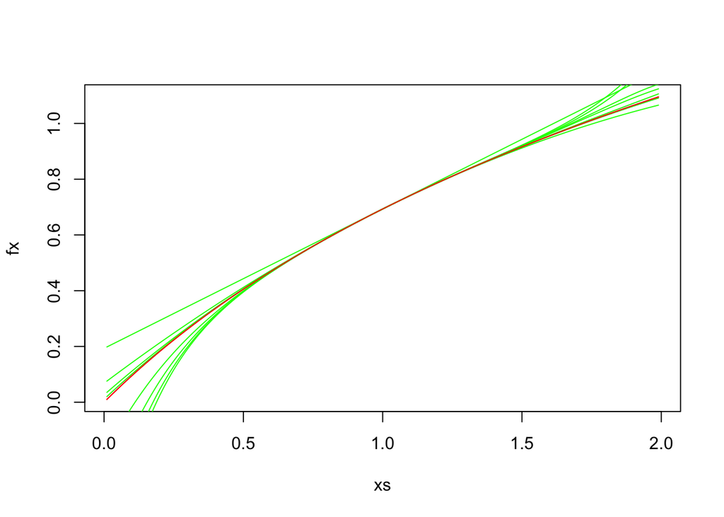

```r
f <- function(x) {
  return(log(1 + x))
}

graph_taylor(f, 1, 0.01, 1.99)
```